# Modelización

En este notebook vamos a buscar el modelo que mejor se ajuste a nuestro problema de detección de fraude. Probaremos distintos modelos en nuestros datos ya procesados, compararemos distintas métricas y determinaremos qué modelo es capaz de predecir mejor. También discutiremos cuál es la mejor forma de balancear nuestros datos.

Los modelos que vamos a probar son:

- Base
- Random Forest
- Bayes
- GLM
- XGBoost
- Support Vector Machine (SVC)
- LightGBM

### Librerías

```python
import pandas as pd
import numpy as np
import seaborn as sns
from matplotlib import pyplot as plt
from sklearn.model_selection import train_test_split, GridSearchCV, RandomizedSearchCV
from sklearn import metrics
from sklearn.pipeline import Pipeline
from sklearn.ensemble import GradientBoostingClassifier
from sklearn.naive_bayes import GaussianNB
from sklearn.svm import SVC
from sklearn.dummy import DummyClassifier
from sklearn.ensemble import RandomForestClassifier
from sklearn.linear_model import LogisticRegression
from sklearn.metrics import confusion_matrix, recall_score, precision_score, make_scorer, \
                            f1_score, accuracy_score, fbeta_score, ConfusionMatrixDisplay
from imblearn.over_sampling import SMOTE, RandomOverSampler
from imblearn.under_sampling import RandomUnderSampler
from lightgbm import LGBMClassifier
import time
import warnings
```

```python
warnings.filterwarnings("ignore")
```

### Función

```python
def pipeline_balanceo(df, modelos, balanceo=False, ratio=0.5, semilla=33):
    '''
    ----------------------------------------------------------------------------------------------------------
    Function pipeline_balanceo:
    ----------------------------------------------------------------------------------------------------------
        -Description: Function that may or may not perform balancing, executes a pipeline testing different models and
        compares them using various metrics
        -Inputs:
            -- df: Pandas dataframe that contains the data to perform the model selection
            -- modelos: list with the models that are going to be executed in the pipeline
            -- balanceo: balance type between SMOTE, RandomUnderSampler and RandomOverSampler
            -- ratio: proportion of the target variable
            -- semilla: number to select the random state
        -Output:
            -- Metrics to compare different models graphically
    '''
    X_train, X_val, y_train, y_val = train_test_split(df.drop(columns=['Unnamed: 0', 'fraud_bool']),
                                                          df['fraud_bool'],
                                                          test_size=0.2,
                                                          stratify=df['fraud_bool'],
                                                          random_state=semilla)
    if ratio <= 0 or ratio >= 1:
        raise ValueError("El ratio debe estar en el rango (0, 1).")

    # Verify that classifiers is a list of classifiers
    if not all(isinstance(classifier, (DummyClassifier, RandomForestClassifier, GaussianNB, LogisticRegression, GradientBoostingClassifier, LGBMClassifier)) for classifier in classifiers):
        raise ValueError("Los clasificadores deben ser instancias de modelos de sklearn.")


    if balanceo is not False and balanceo not in [RandomUnderSampler, RandomOverSampler, SMOTE]:
        raise ValueError("Técnica de balanceo no válida. Debe ser una de: RandomUnderSampler, RandomOverSampler, SMOTE o ninguna")

    elif balanceo is not False and balanceo in [RandomUnderSampler, RandomOverSampler, SMOTE]:
        balance = balanceo(random_state = semilla, sampling_strategy = ratio)
        X_train_balanced, y_train_balanced = balance.fit_resample(X_train, y_train)

    else:
        X_train_balanced = X_train
        y_train_balanced = y_train

    results_df = pd.DataFrame(columns=['Modelo', 'Accuracy', 'Recall', 'Precision', 'F1', 'F2'])

    for classifier in modelos:

        start_time = time.time()

        pipe = Pipeline(steps=[('classifier', classifier)])
        pipe.fit(X_train_balanced, y_train_balanced)

        y_pred_balanced = pipe.predict(X_val)

        end_time = time.time()

        accuracy_balanced = accuracy_score(y_val, y_pred_balanced)
        recall_balanced = recall_score(y_val, y_pred_balanced)
        precision_balanced = precision_score(y_val, y_pred_balanced)
        f1_balanced = f1_score(y_val, y_pred_balanced)
        f2_balanced = fbeta_score(y_val, y_pred_balanced, beta=2)
        matriz_confusion_balanced = confusion_matrix(y_val, y_pred_balanced)


        disp = ConfusionMatrixDisplay(confusion_matrix=matriz_confusion_balanced)
        disp.plot()
        plt.xlabel("Predicción")
        plt.ylabel("Valores Reales")
        plt.title(classifier)
        plt.show()

        # Add results to the DataFrame
        temp_df = pd.DataFrame({
            'Modelo': [str(classifier)],
            'Accuracy': [accuracy_balanced],
            'Recall': [recall_balanced],
            'Precision': [precision_balanced],
            'F1': [f1_balanced],
            'F2': [f2_balanced],
            'Tiempo de ejecución [s]': [end_time - start_time]
        })

        results_df = pd.concat([results_df, temp_df])


    # Visualize the DataFrame
    print(results_df.set_index('Modelo'))
```

### Cargamos los datos

```python
pd_fraude_train_t = pd.read_csv('./data/pd_train_processed.csv')
```

Vamos a dividir nuestro dataset de train nuevamente en train y validation. Como no queremos que los modelos vean nada del test, hacemos esta división y probamos los modelos con el dataset de validation, dejando el test original para el modelo final.

```python
X_train, X_val, y_train, y_val = train_test_split(pd_fraude_train_t.drop(columns=['Unnamed: 0', 'fraud_bool']),
                                                  pd_fraude_train_t['fraud_bool'],
                                                  test_size=0.2,
                                                  stratify=pd_fraude_train_t['fraud_bool'],
                                                  random_state=33)
```

```python
print("Entrenamiento:", "\n", y_train.value_counts(normalize=True))
print("Validación:", "\n", y_val.value_counts(normalize=True))
```

```
Entrenamiento:
 fraud_bool
0    0.988972
1    0.011028
Name: proportion, dtype: float64
Validación:
 fraud_bool
0    0.988969
1    0.011031
Name: proportion, dtype: float64
```

Podemos observar que se conserva la proporción de fraudes entre los conjuntos de train y validation, pero existe un desbalanceo muy evidente en nuestros datos que puede suponer un gran problema a la hora de entrenar.

## Análisis de Modelos

Vamos a analizar cómo funcionan diferentes modelos para nuestro conjunto de datos y elegiremos aquel que mejores resultados tenga. Para evaluar los modelos existen diversas métricas que nos permiten compararlos, pero las que más nos interesan en nuestro caso, son aquellas que reflejen la efectividad de identificar fraudes.

- Accuracy: Esta métrica mide la proporción de predicciones correctas del total de predicciones. Esta métrica la usaremos como métrica auxiliar porque no es tan interesante para nuestro caso, ya que la mayoría de predicciones serán de no fraude porque es la clase mayoritaria. Es decir, si únicamente predecimos que no se comete fraude, tendríamos un valor de accuracy muy alto pero sería una predicción muy mala.
- Precision: Esta métrica mide la proporción de predicciones clasificadas como fraude que realmente son fraudes, es decir, cuanto mayor sea esta métrica, menos predicciones serán clasificadas incorrectamente como fraude.
- Recall: Esta métrica mide la proporción de fraudes que fueron correctamente identificados por el modelo, es decir, cuanto mayor sea esta métrica, menos fraudes serán pasados por alto.
- F2-score: Esta métrica combina precision y recall, proporcionando un equilibrio entre ambas, además funciona especialmente bien cuando el dataset está desbalanceado como en nuestro caso. Preferimos utilizar F2-score antes que F1-score porque le damos un mayor peso al Recall que a la Precision, es decir, es más caro predecir que no se ha cometido fraude y que realmente se haya cometido fraude. Es importante comentar que resulta complicado cuantificar esta importancia, y sería muy interesante hacer un estudio en mayor profundidad.
- Matriz de confusión: esta métrica nos muestra los Verdaderos Positivos y Negativos, y los Falsos Positivos y Negativos. Es muy útil para visualizar claramente todas las predicciones del modelos.

Como nuestro dataset está muy desbalanceado, vamos a hacer una prueba inicial donde comprobemos el F2-score sin hacer ningún tipo de balanceo para ver cómo se comportan los modelos. Para analizar los modelos vamos a utilizar un pipeline, que nos facilita la comparación de los distintos algoritmos.

- Modelo base: Este modelo base va a predecir siempre la clase mayoritaria de nuestro dataset, que es 'no fraude' o '0'. Este modelo lo introducimos en el pipeline para establecer una línea de referencia en la evaluación del rendiemiento del resto de modelos.
- Random Forest: Este modelo es una combinación de muchos Árboles de Decisión donde cada árbol hace una predicción sobre la variable objetivo y aquella con mayor número de predicciones se considera la predicción final. Es un modelo robusto que funciona muy bien con datos desbalanceados.
- Bayes: Este modelo se basa en el teorema de Bayes y asume independencia condicional entre las características dadas las clases. Es un modelo rápido y fácil de implementar.
- GLM: Es un modelo de regresión logística y es especialmente útil para problemas de clasificación binaria, como es nuestro caso.
- XGBoost: Es un algoritmo de aprendizaje de gradient boosting que es robusto, eficiente y permite la manipulación de muchos hiperparámetros para optimizar el rendimiento del modelo.
- Support Vector Machine: Este modelo busca encontrar el hiperplano que mejor separa las clases. Es efectivo en espacios de alta dimensión y puede manejar conjuntos de datos no lineales mediante el uso de kernels. Es útil cuando la relación entre las características y la clase es compleja. Debido al gran tiempo de ejecución que requiere este modelo, lo vamos a ejecutar individualmente fuera del pipeline, y con un tamaño de datos menor al que utilizaremos con el resto de modelos.
- LigthGBM: Similar a XGBoost, LightGBM es un modelo de gradient boosting que se enfoca en la velocidad y el rendimiento. Es especialmente útil en conjuntos de datos grandes y es capaz de manejar datos desbalanceados.

```python
%%time

classifiers = [
    DummyClassifier(),
    RandomForestClassifier(),
    GaussianNB(),
    LogisticRegression(),
    GradientBoostingClassifier(),
    LGBMClassifier()
    ]

for classifier in classifiers:
    pipe = Pipeline(steps=[('classifier', classifier)])
    pipe.fit(X_train, y_train)
    y_pred = pipe.predict(X_val)
    f2 = fbeta_score(y_val, y_pred, beta=2)
    print(classifier)
    print("F2 score: %.3f" % f2, '\n')
```

```
DummyClassifier()
F2 score: 0.000

RandomForestClassifier()
F2 score: 0.001

GaussianNB()
F2 score: 0.163

LogisticRegression()
F2 score: 0.005

GradientBoostingClassifier()
F2 score: 0.020

[LightGBM] [Info] Number of positive: 7058, number of negative: 632942
[LightGBM] [Info] Auto-choosing row-wise multi-threading, the overhead of testing was 0.027005 seconds.
You can set `force_row_wise=true` to remove the overhead.
And if memory is not enough, you can set `force_col_wise=true`.
[LightGBM] [Info] Total Bins 2536
[LightGBM] [Info] Number of data points in the train set: 640000, number of used features: 37
[LightGBM] [Info] [binary:BoostFromScore]: pavg=0.011028 -> initscore=-4.496217
[LightGBM] [Info] Start training from score -4.496217
LGBMClassifier()
F2 score: 0.033

CPU times: total: 8min 32s
Wall time: 8min 27s
```

Como podemos observar, los resultados obtenidos no parecen muy buenos. Esto se puede deber a que el conjunto de datos está desbalanceado, por lo que los modelos están sesgados hacia la clase mayoritaria y aprenden a predecir predominantemente esta clase, sin prestar suficiente atención a la clase minoritaria.

## Balanceo de los datos

Existen distintas técnicas de balanceo de datos, entre las más comunes están el Oversampling y Undersampling.

- Oversampling: Consiste en aumentar el número de instancias de la clase minoritaria con el objetivo de equilibrar la distribución de clases.
- Undersampling: Es el contrario del oversampling. Consiste en reducir el número de instancias de la clase mayoritaria para equilibrar la distribución de clases.

En nuestro caso de detección de fraudes, existe una gran desproporción de clases donde hay muy pocos casos de fraude en relación al no fraude. Teniendo esto en cuenta, pensamos que la mejor opción es utilizar una técnica de oversampling, con el fin de generar más instacias de fraude, que es lo que más nos interesa de cara a entrenar un modelo. En concreto, vamos a utilizar la técnica SMOTE, que crea instancias sintéticas de la clase minoritaria a través de la interpolación de instancias existentes.

Un aspecto negativo de utilizar una técnica de oversampling es el tiempo de ejecución, ya que al estar creando instancias sintéticas, los modelos tienen que procesar una mayor cantidad de datos durante la etapa de entrenamiento.

### Smote

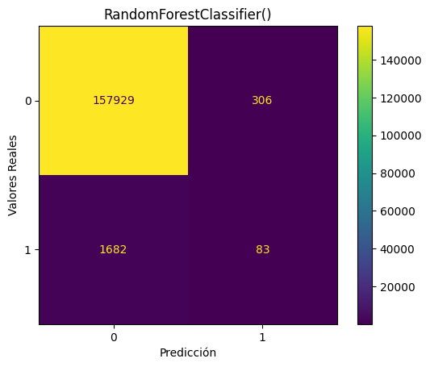

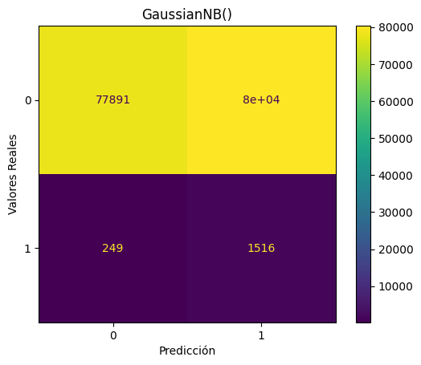

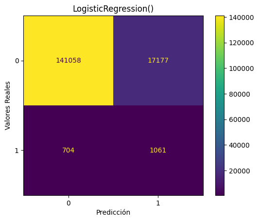

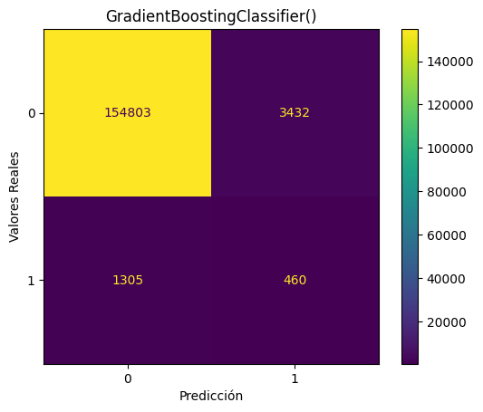

[output not shown]

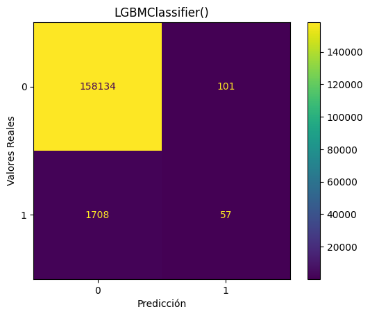

```
                              Accuracy    Recall  Precision        F1  \
Modelo
DummyClassifier()             0.988969  0.000000   0.000000  0.000000
RandomForestClassifier()      0.987575  0.047025   0.213368  0.077066
GaussianNB()                  0.496294  0.858924   0.018519  0.036257
LogisticRegression()          0.888244  0.601133   0.058175  0.106084
GradientBoostingClassifier()  0.970394  0.260623   0.118191  0.162630
LGBMClassifier()              0.988694  0.032295   0.360759  0.059282

                                    F2  Tiempo de ejecución [s]
Modelo
DummyClassifier()             0.000000                 0.029214
RandomForestClassifier()      0.055712               410.899320
GaussianNB()                  0.085245                 0.769615
LogisticRegression()          0.209700                 1.619404
GradientBoostingClassifier()  0.210007               571.763588
LGBMClassifier()              0.039485                 3.545678
```

```python
pipeline_balanceo(df=pd_fraude_train_t, modelos=classifiers, balanceo=SMOTE)
```

El oversampling que acabamos de realizar hace un balanceo del 50% para cada clase, y puede que de esta forma de esté produciendo igualmente algo de overfitting. Por este motivo, vamos a probar a reducir la proporción de la clase objetivo a un 35% y un 20% de la muestra y analizar esos resultados. Esto lo conseguimos modificando el parámetro 'sampling_strategy' dentro de la función SMOTE.

Además, vamos a intentar reducir el tiempo de ejecución, ya que este SMOTE ha tardado más de 30 minutos en ejecutar.

### Smote 35%

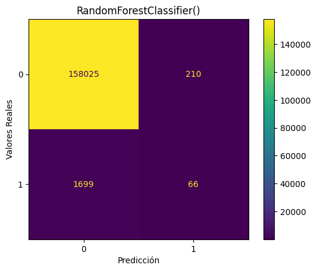

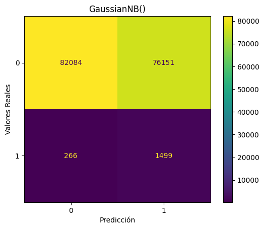

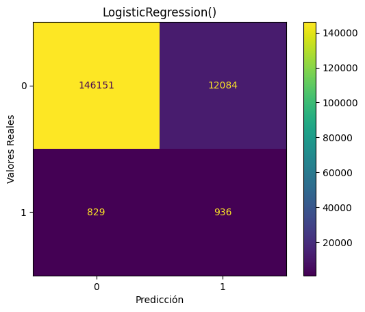

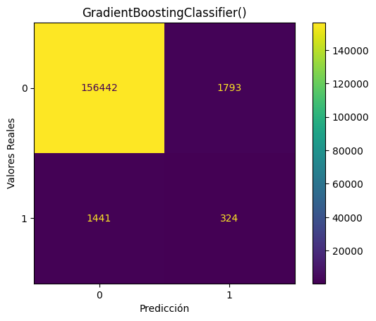

[output not shown]

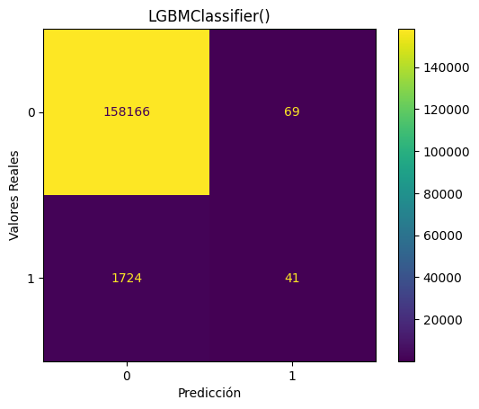

```
                              Accuracy    Recall  Precision        F1  \
Modelo
DummyClassifier()             0.988969  0.000000   0.000000  0.000000
RandomForestClassifier()      0.988069  0.037394   0.239130  0.064674
GaussianNB()                  0.522394  0.849292   0.019305  0.037751
LogisticRegression()          0.919294  0.530312   0.071889  0.126615
GradientBoostingClassifier()  0.979788  0.183569   0.153047  0.166924
LGBMClassifier()              0.988794  0.023229   0.372727  0.043733

                                    F2  Tiempo de ejecución [s]
Modelo
DummyClassifier()             0.000000                 0.022559
RandomForestClassifier()      0.044984               330.820225
GaussianNB()                  0.088478                 0.539992
LogisticRegression()          0.233068                 1.367852
GradientBoostingClassifier()  0.176528               496.883632
LGBMClassifier()              0.028591                 3.216006
```

```python
pipeline_balanceo(df=pd_fraude_train_t, modelos=classifiers, balanceo=SMOTE, ratio=0.35)
```

### Smote 20%

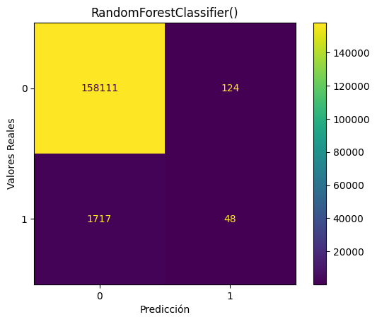

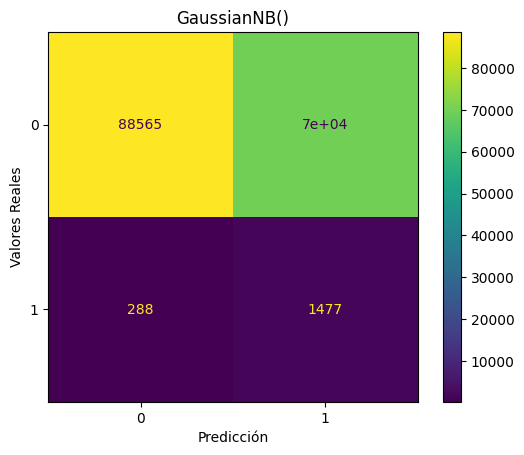

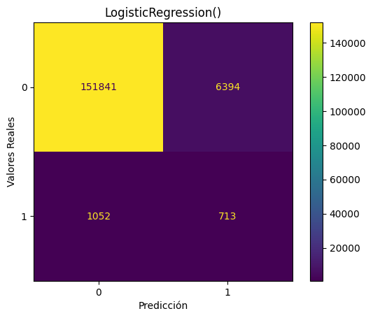

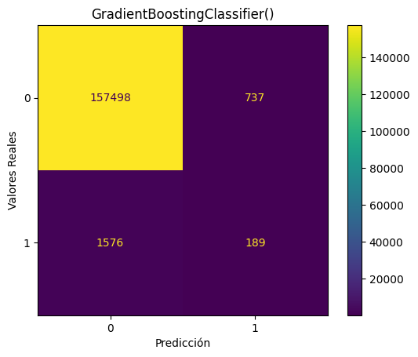

[output not shown]

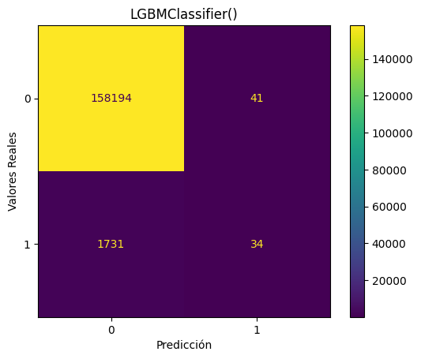

```
                              Accuracy    Recall  Precision        F1  \
Modelo
DummyClassifier()             0.988969  0.000000   0.000000  0.000000
RandomForestClassifier()      0.988494  0.027195   0.279070  0.049561
GaussianNB()                  0.562763  0.836827   0.020760  0.040515
LogisticRegression()          0.953462  0.403966   0.100324  0.160730
GradientBoostingClassifier()  0.985544  0.107082   0.204104  0.140468
LGBMClassifier()              0.988925  0.019263   0.453333  0.036957

                                    F2  Tiempo de ejecución [s]
Modelo
DummyClassifier()             0.000000                 0.021567
RandomForestClassifier()      0.033186               276.546814
GaussianNB()                  0.094429                 0.571568
LogisticRegression()          0.251641                 1.308458
GradientBoostingClassifier()  0.118332               387.037091
LGBMClassifier()              0.023826                 2.820424
```

```python
pipeline_balanceo(df=pd_fraude_train_t, modelos=classifiers, balanceo=SMOTE, ratio=0.2)
```

Lo primero que podemos observar de los resultados es que los tiempos de ejecución, aun siendo elevados, son menores que el SMOTE con un 'samplig_strategy' del 50%, con unos tiempos algo superiores a 10 minutos cada uno.

Comparándo las métricas, parece que los que mejor funcionan siguen siendo el XGBoost y el GLM, pero ahora nos da mejores resultados el GLM sobre el XGBoost. Además, funciona mejor la técnica SMOTE reduciendo la proporción de la clase objetivo a un 20%, donde conseguimos un F2-score de 0.25 en el GLM y con menor tiempo de ejecución.

El resto de modelos predicen bastante mal, siendo el RandomForest y el LightGBM que prácticamente predicen que no hay fraude nunca, y el modelo de Bayes que predice casi al azar con valores de accuracy de 0.56 y 0.52.

### RandomUnderSampler

Otra opción a la hora de balancear un dataset, es realizar un undersampling. Vamos a probar cómo varían los las métricas de los modelos si aplicamos un balanceo por undersampling en lugar de un SMOTE, y si esto sirve para reducir el tiempo de ejecución. Hemos decidido utilizar un RandomUnderSampler, un técnica que selecciona aleatoriamente instancias de la clase mayoritaria y mantiene todas las instancias de la clase minoritaria, y como es aleatorio es bastante fácil de implementar. Otras opciones que hemos considerado para el undersampling son NearMiss y Tomek Links, pero al querer dar mayor importancia a la sencillez hemos decidido utilizar RandomUnderSampler.

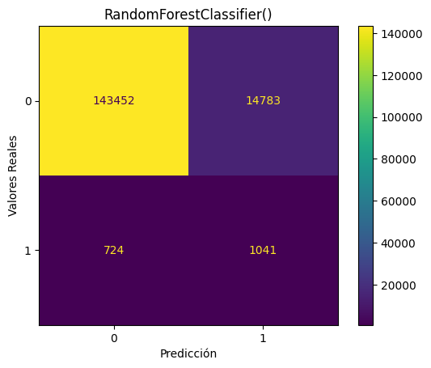

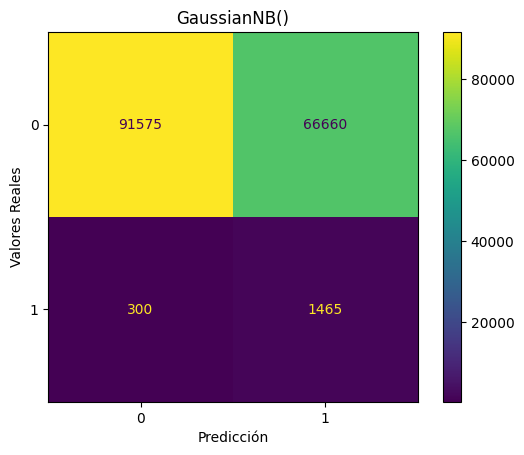

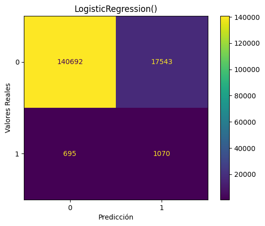

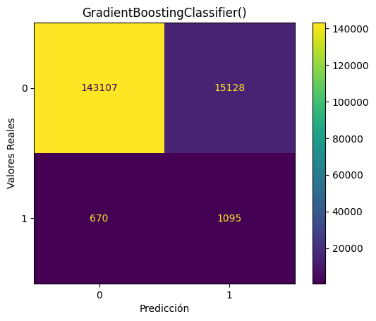

[output not shown]

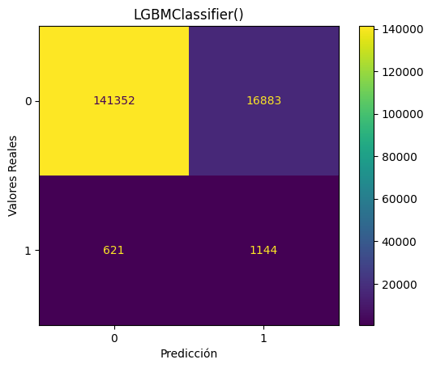

```
                              Accuracy    Recall  Precision        F1  \
Modelo
DummyClassifier()             0.988969  0.000000   0.000000  0.000000
RandomForestClassifier()      0.903081  0.589802   0.065786  0.118369
GaussianNB()                  0.581500  0.830028   0.021505  0.041923
LogisticRegression()          0.886012  0.606232   0.057487  0.105015
GradientBoostingClassifier()  0.901262  0.620397   0.067497  0.121748
LGBMClassifier()              0.890600  0.648159   0.063460  0.115602

                                    F2  Tiempo de ejecución [s]
Modelo
DummyClassifier()             0.000000                 0.002000
RandomForestClassifier()      0.227451                 7.697719
GaussianNB()                  0.097426                 0.088246
LogisticRegression()          0.208390                 0.036058
GradientBoostingClassifier()  0.235150                 8.044853
LGBMClassifier()              0.228007                 0.334307
```

```python
pipeline_balanceo(df=pd_fraude_train_t, modelos=classifiers, balanceo=RandomUnderSampler)
```

Vemos que efectivamente el tiempo de ejecución se ha reducido enormemente, siendo este un poco mayor a 10 segundos.

Vamos a hacer lo mismo que con SMOTE, probar distintos niveles de balanceo y ver si así los modelos predicen mejor.

### RandomUnderSampler 35%

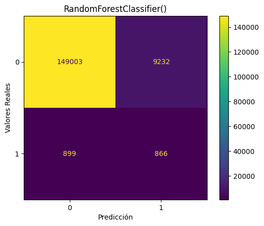

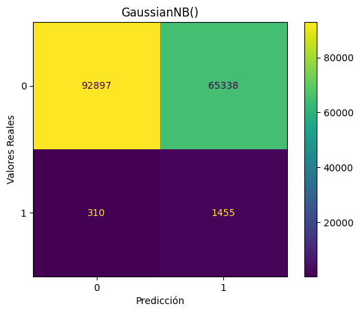

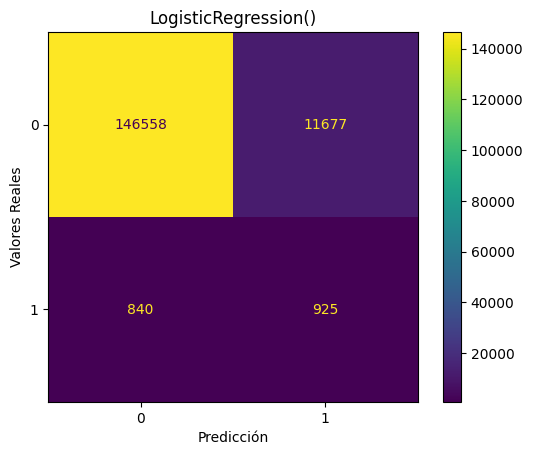

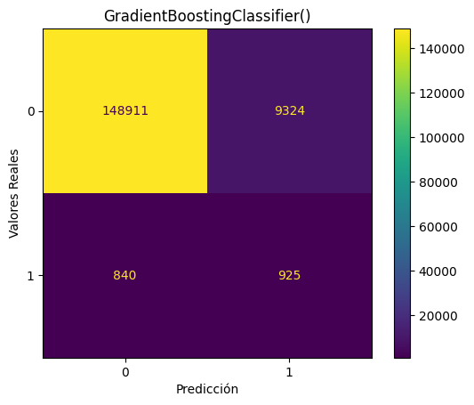

[output not shown]

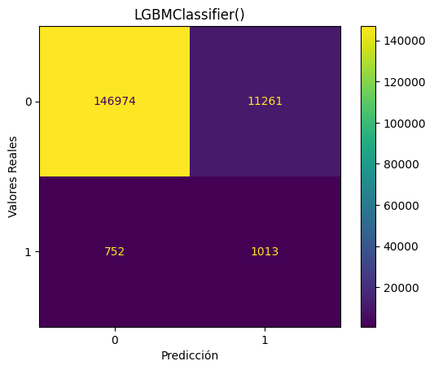

```
                              Accuracy    Recall  Precision        F1  \
Modelo
DummyClassifier()             0.988969  0.000000   0.000000  0.000000
RandomForestClassifier()      0.936681  0.490652   0.085760  0.146000
GaussianNB()                  0.589700  0.824363   0.021784  0.042446
LogisticRegression()          0.921769  0.524079   0.073401  0.128767
GradientBoostingClassifier()  0.936475  0.524079   0.090253  0.153987
LGBMClassifier()              0.924919  0.573938   0.082532  0.144312

                                    F2  Tiempo de ejecución [s]
Modelo
DummyClassifier()             0.000000                 0.002003
RandomForestClassifier()      0.252360                 9.598316
GaussianNB()                  0.098506                 0.083467
LogisticRegression()          0.235225                 0.042859
GradientBoostingClassifier()  0.267202                10.093240
LGBMClassifier()              0.261974                 0.312726
```

```python
pipeline_balanceo(df=pd_fraude_train_t, modelos=classifiers, balanceo=RandomUnderSampler, ratio=0.35)
```

### RandomUnderSampler 20%

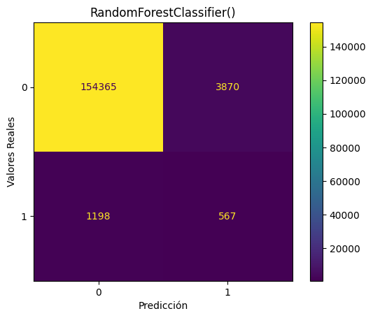

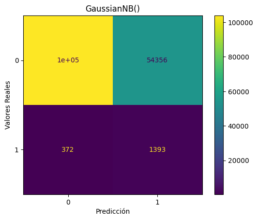

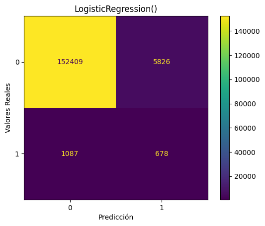

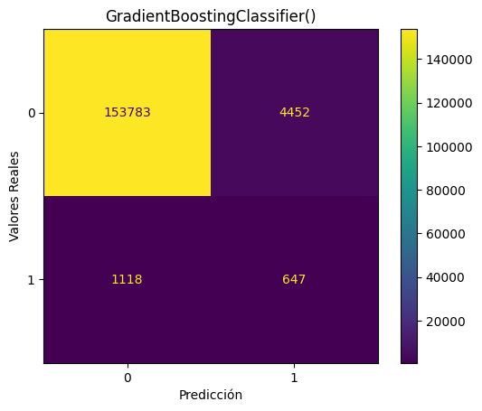

[output not shown]

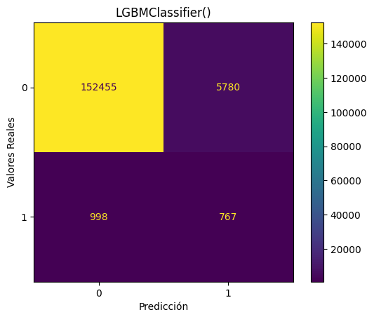

```
                              Accuracy    Recall  Precision        F1  \
Modelo
DummyClassifier()             0.988969  0.000000   0.000000  0.000000
RandomForestClassifier()      0.968325  0.321246   0.127789  0.182844
GaussianNB()                  0.657950  0.789235   0.024987  0.048440
LogisticRegression()          0.956794  0.384136   0.104244  0.163986
GradientBoostingClassifier()  0.965187  0.366572   0.126888  0.188520
LGBMClassifier()              0.957638  0.434561   0.117153  0.184552

                                    F2  Tiempo de ejecución [s]
Modelo
DummyClassifier()             0.000000                 0.003000
RandomForestClassifier()      0.246586                13.529755
GaussianNB()                  0.110892                 0.090785
LogisticRegression()          0.249926                 0.066894
GradientBoostingClassifier()  0.266058                15.649139
LGBMClassifier()              0.281840                 0.419951
```

```python
pipeline_balanceo(df=pd_fraude_train_t, modelos=classifiers, balanceo=RandomUnderSampler, ratio=0.2)
```

En cuanto a los modelos, vemos que funcionan generalmente bien el RandomForest, GLM, XGBoost y LightGBM, todos estos obtienen un F2-score mayor a 0.23 tanto con un 35 y 20% de clase minoritaria y tienen un rendimiento similar. Elegir el modelo que mejor funciona resulta un poco complicado, y la mayor diferencia que se observa entre el 35 y 20%, es el equilibrio entre recall y precision. Vemos que al usar un 35% de clase minoritaria, hay una mayor diferencia entre recall y precision que si usamos un 20%, por lo que nosotros pensamos que es mejor conservar este equilibro entre métricas. Después, el modelo que mejor funciona con un 20% de la clase minoritaria es el LightGBM, es el que consigue un mayor F2-score con un 0.28, con la ventaja añadida de que es bastante rápido.

## SVC

Como el algoritmo de SVC tarda demasiado tiempo en entrenar, vamos a probarlo por separado con un tamaño de la muestra más pequeño, un 15% de los datos que hemos usado para el resto de modelos.

```python
X_train_svc, X_unused, y_train_svc, y_unused = train_test_split(X_train, y_train,
                                                                test_size=0.85, stratify=y_train, random_state=33)

X_val_svc, X_val_unused, y_val_svc, y_val_unused = train_test_split(X_val, y_val,
                                                                    test_size=0.85, stratify=y_val, random_state=33)

print(X_train_svc.shape, X_val_svc.shape)
```

```
(96000, 37) (24000, 37)
```

```python
under_20 = RandomUnderSampler(random_state=33, sampling_strategy=0.2)

X_train_svc_under, y_train_svc_under = under_20.fit_resample(X_train_svc, y_train_svc)

X_train_svc_under.shape
```

```
(6354, 37)
```

```python
%%time

svc_model = SVC()

svc_model.fit(X_train_svc_under, y_train_svc_under)
```

```
CPU times: total: 656 ms
Wall time: 673 ms
```

```
SVC()
```

```
SVC
Accuracy score: 0.965
Recall score: 0.351
Precision score: 0.120
F1 score: 0.179
F2 score: 0.254
```

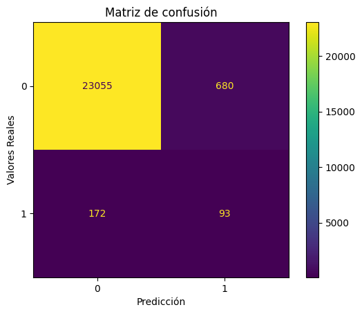

```
CPU times: total: 4.31 s
Wall time: 4.38 s
```

```python
%%time

y_pred_svc = svc_model.predict(X_val_svc)

accuracy_svc = accuracy_score(y_val_svc, y_pred_svc)
recall_svc = recall_score(y_val_svc, y_pred_svc)
precision_svc = precision_score(y_val_svc, y_pred_svc)
f1_svc = f1_score(y_val_svc, y_pred_svc)
f2_svc = fbeta_score(y_val_svc, y_pred_svc, beta=2)
matriz_confusion_svc = confusion_matrix(y_val_svc, y_pred_svc)

print("SVC")
print("Accuracy score: %.3f" % accuracy_svc)
print("Recall score: %.3f" % recall_svc)
print("Precision score: %.3f" % precision_svc)
print("F1 score: %.3f" % f1_svc)
print("F2 score: %.3f" % f2_svc)

disp = ConfusionMatrixDisplay(confusion_matrix=matriz_confusion_svc)
disp.plot()
plt.xlabel("Predicción")
plt.ylabel("Valores Reales")
plt.title("Matriz de confusión")
plt.show()
```

Los resultados que obtenemos con este modelo utilizando un RandomUnderSampler con un 20% de la variable objetivo son similares a los que obtenemos con los modelos del pipeline, pero el tiempo de ejecución tan elevado hace que no podamos seleccionar este modelo.

Después de hacer la reducción del conjunto de datos para poder entrenarlo y aplicarle un Undersampling, el tiempo de ejecución es bastante bajo, pero inicialmente cuando lo probamos en el pipeline se quedaba ejecutando durante varias horas y no finalizaba. Por esta razón, no vamos a considerar seleccionar este modelo

## Conclusión

Finalmente, después de haber probado varios modelos aplicando distintas técnicas de balanceo, hemos a quedarnos con el balanceo por undersampling y seleccionando un 20% de la clase minoritaria debido a su rapidez y que hemos obtenido los mejores resultados con esta técnica. Y como modelo vamos a seleccionar el LightGBM ya que nos ha proporcionado los mejores resultados y también es bastante rápido. Podríamos haber seleccionado RandomForest o XGBoost porque tenían unos resultados similares, pero los tiempos de ejecucción eran mayores en estos modelos.

Cuando las métricas que se obtienen son tan similares entre varios modelos, el tiempo se vuelve un factor clave ya que agiliza todo el proceso y eso se traduce en una reducción de costes y recursos cuando uno se encuentra trabajando en una gran empresa.